# DATA 624: Project 2

Wei Zhou

12/11/2020

# Data Exploration

```r
# "Student" soft drink data
ph_data <- read.csv("./project2/StudentData.csv", na.strings = c("", " "), stringsAsFactors = FALSE)
# convert values read as integers to numeric
ph_data[, c(16, 18, 21, 28)] <- sapply(ph_data[, c(16, 18, 21, 28)], as.numeric)
```

The structure of the data is presented below:

```r
str(ph_data)
```

```
'data.frame':   2571 obs. of  33 variables:
 $ Brand.Code       : chr  "B" "A" "B" "A" ...
 $ Carb.Volume      : num  5.34 5.43 5.29 5.44 5.49 ...
 $ Fill.Ounces      : num  24 24 24.1 24 24.3 ...
 $ PC.Volume        : num  0.263 0.239 0.263 0.293 0.111 ...
 $ Carb.Pressure    : num  68.2 68.4 70.8 63 67.2 66.6 64.2 67.6 64.2 72 ...
 $ Carb.Temp        : num  141 140 145 133 137 ...
 $ PSC              : num  0.104 0.124 0.09 NA 0.026 0.09 0.128 0.154 0.132 0.014 ...
 $ PSC.Fill         : num  0.26 0.22 0.34 0.42 0.16 0.24 0.4 0.34 0.12 0.24 ...
 $ PSC.CO2          : num  0.04 0.04 0.16 0.04 0.12 0.04 0.04 0.04 0.14 0.06 ...
 $ Mnf.Flow         : num  -100 -100 -100 -100 -100 -100 -100 -100 -100 -100 ...
 $ Carb.Pressure1   : num  119 122 120 115 118 ...
 $ Fill.Pressure    : num  46 46 46 46.4 45.8 45.6 51.8 46.8 46 45.2 ...
 $ Hyd.Pressure1    : num  0 0 0 0 0 0 0 0 0 0 ...
 $ Hyd.Pressure2    : num  NA NA NA 0 0 0 0 0 0 0 ...
```

[output cut: 19 more lines]

The data contains 2571 observations across 33 variables. The first variable, `Brand.Code`, is a character; the remaining 32 variables are numeric. Summary statistics of the variables are presented below:

```r
library(e1071)
library(pander)
means <- sapply(ph_data[-1], function(y) mean(y, na.rm = TRUE))
medians <- sapply(ph_data[-1], function(y) median(y, na.rm = TRUE))
IQRs <- sapply(ph_data[-1], function(y) IQR(y, na.rm = TRUE))
vars <- sapply(ph_data[-1], function(y) var(y, na.rm = TRUE))
skews <- sapply(ph_data[-1], function(y) skewness(as.numeric(y), na.rm = TRUE))
cors <- as.vector(cor(ph_data$PH, ph_data[,2:ncol(ph_data)], use = "complete.obs"))
NAs <- sapply(ph_data[-1], function(y) sum(length(which(is.na(y)))))
soda_summary <- data.frame(means, medians, IQRs, vars, skews, cors, NAs)
colnames(soda_summary) <- c("MEAN", "MEDIAN", "IQR", "Var", "SKEW", "$r_{PH}$", "NAs")
soda_summary <- round(soda_summary, 2)
pander(soda_summary)
```

|  | MEAN | MEDIAN | IQR | Var | SKEW | $r_{PH}$ | NAs |
| --- | --- | --- | --- | --- | --- | --- | --- |
| **Carb.Volume** | 5.37 | 5.35 | 0.16 | 0.01 | 0.39 | 0.07 | 10 |
| **Fill.Ounces** | 23.97 | 23.97 | 0.11 | 0.01 | -0.02 | -0.12 | 38 |
| **PC.Volume** | 0.28 | 0.27 | 0.07 | 0 | 0.34 | 0.1 | 39 |
| **Carb.Pressure** | 68.19 | 68.2 | 5 | 12.52 | 0.18 | 0.08 | 27 |
| **Carb.Temp** | 141.1 | 140.8 | 5.4 | 16.3 | 0.25 | 0.03 | 26 |
| **PSC** | 0.08 | 0.08 | 0.06 | 0 | 0.85 | -0.07 | 33 |
| **PSC.Fill** | 0.2 | 0.18 | 0.16 | 0.01 | 0.93 | -0.02 | 23 |
| **PSC.CO2** | 0.06 | 0.04 | 0.06 | 0 | 1.73 | -0.09 | 39 |
| **Mnf.Flow** | 24.57 | 65.2 | 240.8 | 14276 | 0 | -0.46 | 2 |
| **Carb.Pressure1** | 122.6 | 123.2 | 6.4 | 22.49 | 0.05 | -0.12 | 32 |
| **Fill.Pressure** | 47.92 | 46.4 | 4 | 10.1 | 0.55 | -0.32 | 22 |
| **Hyd.Pressure1** | 12.44 | 11.4 | 20.2 | 154.6 | 0.78 | -0.05 | 11 |
| **Hyd.Pressure2** | 20.96 | 28.6 | 34.6 | 268.5 | -0.3 | -0.22 | 15 |
| **Hyd.Pressure3** | 20.46 | 27.6 | 33.4 | 255.2 | -0.32 | -0.27 | 15 |
| **Hyd.Pressure4** | 96.29 | 96 | 16 | 172.2 | 0.55 | -0.17 | 30 |
| **Filler.Level** | 109.2 | 118.4 | 21.7 | 246.4 | -0.85 | 0.35 | 20 |
| **Filler.Speed** | 3687 | 3982 | 110 | 594164 | -2.87 | -0.04 | 57 |
| **Temperature** | 65.97 | 65.6 | 1.2 | 1.91 | 2.39 | -0.18 | 14 |
| **Usage.cont** | 20.99 | 21.79 | 5.39 | 8.87 | -0.54 | -0.36 | 5 |
| **Carb.Flow** | 2468 | 3028 | 2042 | 1152824 | -0.99 | 0.23 | 2 |
| **Density** | 1.17 | 0.98 | 0.72 | 0.14 | 0.53 | 0.1 | 1 |
| **MFR** | 704 | 724 | 24.7 | 5461 | -5.09 | -0.05 | 212 |
| **Balling** | 2.2 | 1.65 | 1.8 | 0.87 | 0.59 | 0.08 | 1 |
| **Pressure.Vacuum** | -5.22 | -5.4 | 0.6 | 0.32 | 0.53 | 0.22 | 0 |
| **PH** | 8.55 | 8.54 | 0.24 | 0.03 | -0.29 | 1 | 4 |
| **Oxygen.Filler** | 0.05 | 0.03 | 0.04 | 0 | 2.66 | 0.16 | 12 |
| **Bowl.Setpoint** | 109.3 | 120 | 20 | 234.2 | -0.97 | 0.36 | 2 |
| **Pressure.Setpoint** | 47.62 | 46 | 4 | 4.16 | 0.2 | -0.31 | 12 |
| **Air.Pressurer** | 142.8 | 142.6 | 0.8 | 1.47 | 2.25 | -0.01 | 0 |
| **Alch.Rel** | 6.9 | 6.56 | 0.7 | 0.26 | 0.88 | 0.17 | 9 |
| **Carb.Rel** | 5.44 | 5.4 | 0.2 | 0.02 | 0.5 | 0.2 | 10 |
| **Balling.Lvl** | 2.05 | 1.48 | 1.76 | 0.76 | 0.59 | 0.11 | 1 |

## Missing Values

As shown in the above summary, there are missing values across the variables -- the frequency and pattern of these missing values are presented below:

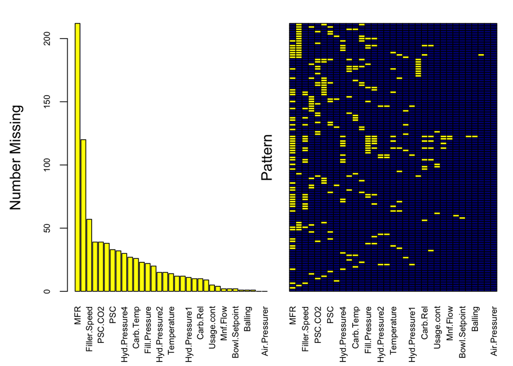

```
 Variables sorted by number of missings:
          Variable Count
               MFR   212
        Brand.Code   120
      Filler.Speed    57
         PC.Volume    39
           PSC.CO2    39
       Fill.Ounces    38
               PSC    33
    Carb.Pressure1    32
     Hyd.Pressure4    30
     Carb.Pressure    27
         Carb.Temp    26
          PSC.Fill    23
     Fill.Pressure    22
      Filler.Level    20
     Hyd.Pressure2    15
     Hyd.Pressure3    15
       Temperature    14
     Oxygen.Filler    12
 Pressure.Setpoint    12
     Hyd.Pressure1    11
       Carb.Volume    10
          Carb.Rel    10
          Alch.Rel     9
        Usage.cont     5
                PH     4
          Mnf.Flow     2
         Carb.Flow     2
     Bowl.Setpoint     2
           Density     1
           Balling     1
       Balling.Lvl     1
   Pressure.Vacuum     0
     Air.Pressurer     0
```

```r
library(VIM)
aggr(ph_data, sortVars = TRUE, bar = FALSE, prop = FALSE, gap = 1, cex.axis = 0.7,
     col = c("navyblue", "yellow"), ylab = c("Number Missing", "Pattern"))
```

The variable `MFR` has over 200 missing values, and the variable `Brand.Code` is missing 120 values. Due to these high proportions of missingness, observations missing these variables are dropped:

```r
library(plyr) # loaded for later dependecies to avoid conflicts with dplyr
library(tidyverse)
ph_data <- drop_na(ph_data, MFR, Brand.Code)
```

Numeric variables are plotted below to determine the best method of imputation:

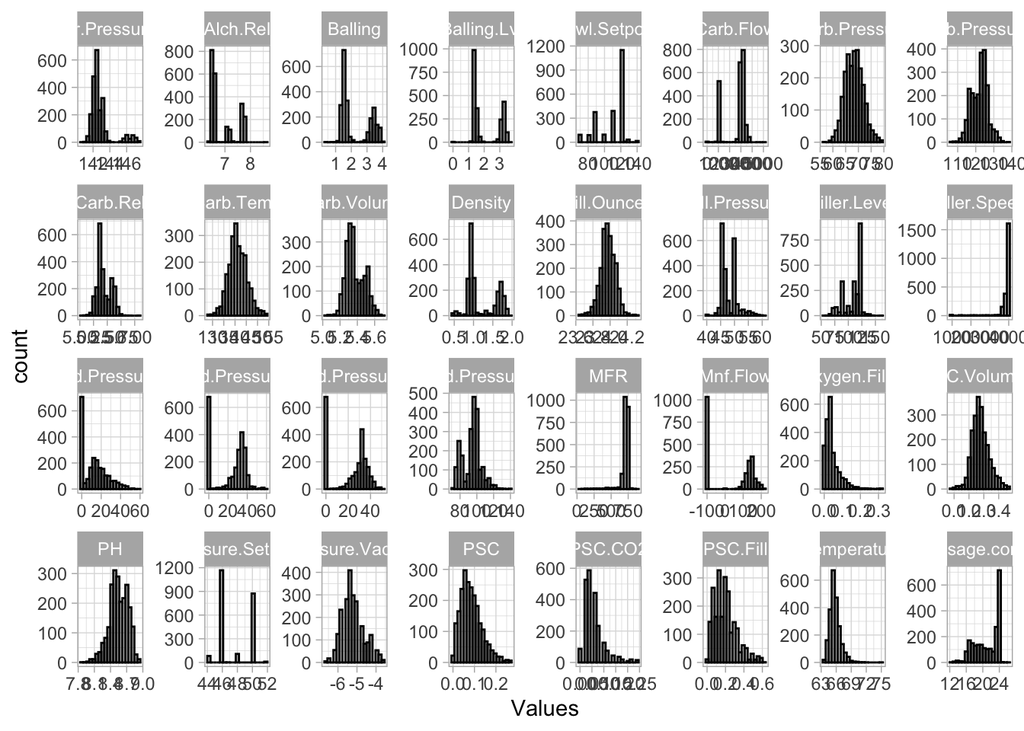

```r
theme_set(theme_light())
ph_data %>%
  select(-Brand.Code) %>%
  gather(Variable, Values) %>%
  ggplot(aes(x = Values)) +
  geom_histogram(alpha = 0.25, col = "black", bins = 20) +
  facet_wrap(~ Variable, scales = "free", nrow = 4)
```

Many of the variables have normal or somewhat-normal distributions, and appear to be continuous variables. Many of the variables show varying levels of skewness, and a few of the skewed distributions follow an almost chi-squared or log-normal distribution. These are predictors (`PSC.Distribution` and `PSC.C02.Distribution`) where transformations should be considered.

Another interesting pattern are the number of 0 values in the `Hyd.Pressure`(1-3) variables. The $4^{th}$ `Hyd.Pressure` does not follow this same pattern, so depending on the relationship between these variables and the target and/or other variables, they may be removed outright.

Some of the predictors appear to be discrete, rather than continuous distributions (`Pressure.Setpoint`, `Alch.Rel`), however, many of these variables are just constrained to a few values, but are still continuous. Out of all the variables, `Bowl.Setpoint` does seem to be a discrete distribution. A table of all values in the variable is below:

```r
pander(table(ph_data$Bowl.Setpoint))
```

| 70 | 80 | 90 | 100 | 110 | 120 | 122 | 126 | 130 | 134 | 140 |
| --- | --- | --- | --- | --- | --- | --- | --- | --- | --- | --- |
| 93 | 89 | 376 | 95 | 390 | 1148 | 1 | 8 | 33 | 1 | 16 |

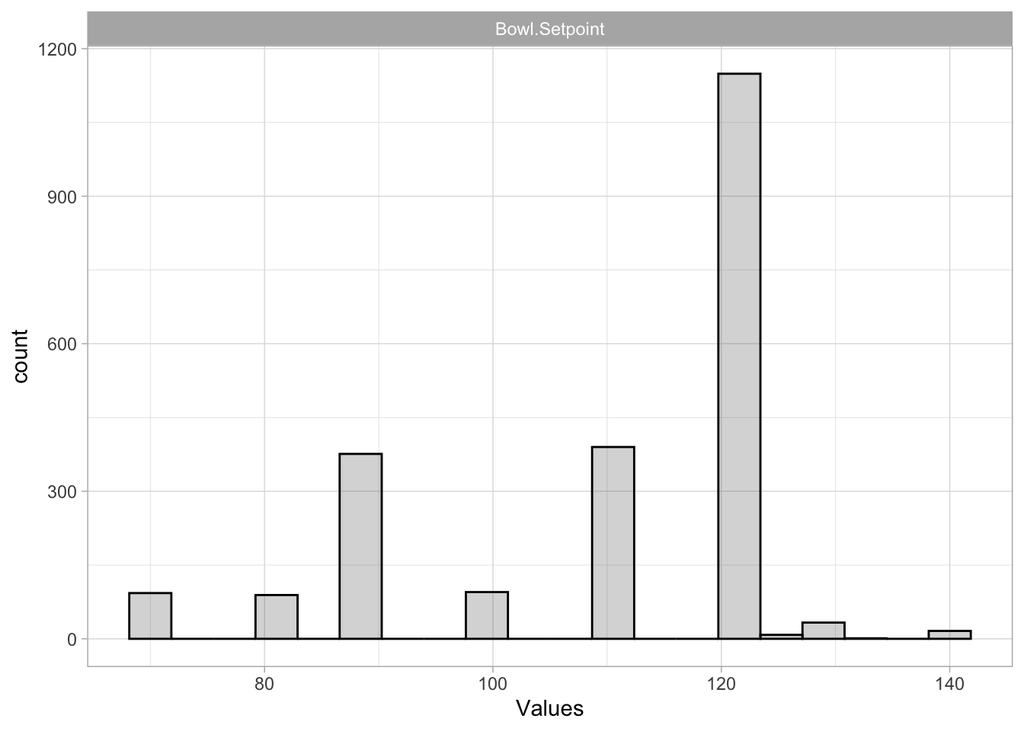

```r
ph_data %>%
  select(Bowl.Setpoint) %>%
  gather(Variable, Values) %>%
  ggplot(aes(x = Values)) +
  geom_histogram(alpha = 0.25, col = "black", bins = 20) +
  facet_wrap(~ Variable, scales = "free", nrow = 4)
```

Boxplots provide an alternate view that allows the spread of the data to be viewed a little more clearly, as well as the presence of outliers and their quantities:

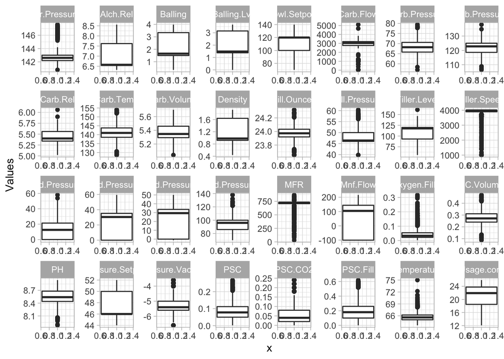

```r
ph_data %>%
  select(-Brand.Code) %>%
  gather(Variable, Values) %>%
  ggplot(aes(x = 1, y = Values)) +
  geom_boxplot() +
  facet_wrap(~ Variable, scales = "free", nrow = 4)
```

A number of these variables are so highly skewed, such as `Filler.Speed`, `Oxygen.Filler`, `MFR`, and `Air.Pressurer`, that many of the observations for that predictor are recognized as outliers. This suggests that imputing with the mean will not be accurate; an alternate method should be investigated.

Before moving on to correlations between predictors, the relationship between the target variable `PH` and the other predictors is visualized using scatterplots:

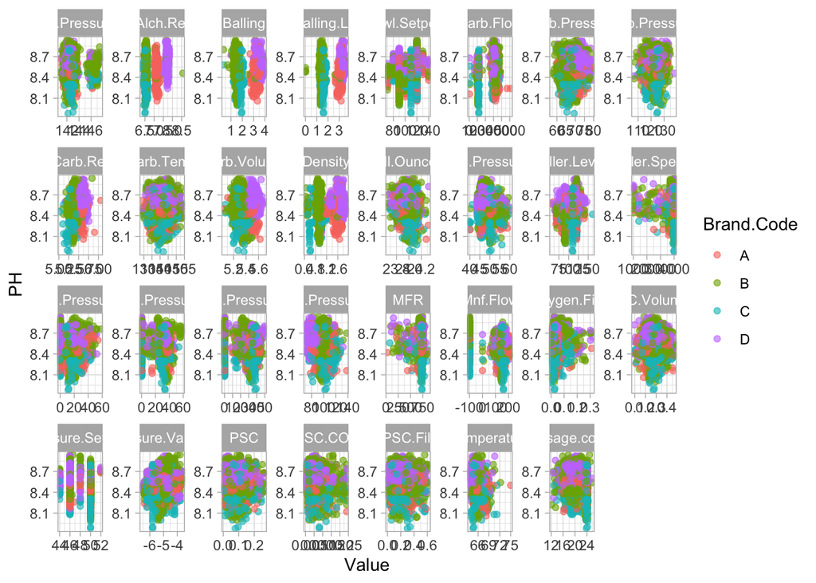

```r
ph_data %>%
  gather(-PH, -Brand.Code, key="Var", value="Value") %>%
  ggplot(aes(x=Value, y=PH, color=Brand.Code)) +
  geom_point(alpha=0.6) +
  facet_wrap(~ Var, scales = "free", nrow=4)
```

Here we see there are no strong patterns (i.e. no defined linear pattern), but there are some relationships between `PH` and the other variables that may be more helpful in predicting the `PH` level of the soft drink. Predictors like `Alch.Rel`, `Density`, and `Temperature` all appear to have a stronger relationship with `PH` - this makes sense, as these variables have more to do with the make-up of the beverage itself, rather than the filling/bottling process.

Also interesting is the clustering of the `Brand.Code` within the plots. As correlations are investigated, this predictor does not have a strong relationship with the target, but combined with other predictors, may be more telling.

## Correlation

The correlation between the variables is investigated:

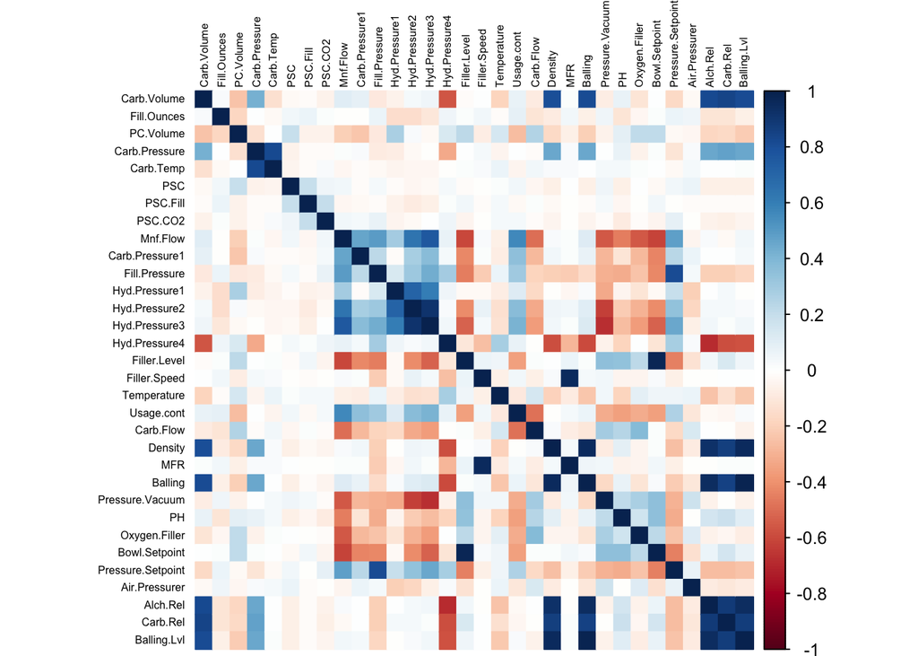

```r
ph_cors <- cor(ph_data %>% select(-Brand.Code), use="complete.obs")
library(corrplot)
corrplot(as.matrix(ph_cors), method = "color", tl.cex = 0.5, tl.col = "black")
```

Some of these same predictors are also correlated well with the target PH variable. The top positive correlations are below:

```r
top_ph_cors <- ph_cors %>%
  as.data.frame() %>%
  select(Correlation = PH) %>%
  rownames_to_column("Variable") %>%
  arrange(desc(Correlation))
top_ph_cors %>%
  top_n(11, Correlation) %>%
  pander()
```

| Variable | Correlation |
| --- | --- |
| PH | 1 |
| Bowl.Setpoint | 0.3585 |
| Filler.Level | 0.3488 |
| Carb.Flow | 0.2408 |
| Pressure.Vacuum | 0.2132 |
| Carb.Rel | 0.1896 |
| Oxygen.Filler | 0.162 |
| Alch.Rel | 0.1561 |
| Balling.Lvl | 0.1033 |
| PC.Volume | 0.09775 |
| Density | 0.09534 |

The predictors with the highest negative correlation to `PH` are as follows:

```r
top_ph_cors %>%
  top_n(-10, Correlation) %>%
  arrange(Correlation) %>%
  pander()
```

| Variable | Correlation |
| --- | --- |
| Mnf.Flow | -0.4572 |
| Usage.cont | -0.3577 |
| Pressure.Setpoint | -0.317 |
| Fill.Pressure | -0.3131 |
| Hyd.Pressure3 | -0.2605 |
| Hyd.Pressure2 | -0.2157 |
| Hyd.Pressure4 | -0.1845 |
| Temperature | -0.1815 |
| Fill.Ounces | -0.1182 |
| Carb.Pressure1 | -0.1121 |

### Intercorrelated Predictors

In addition, some of the variables are highly correlated with each other. The following pairings seem to have something to do with each other in the bottle filling process:

```r
library(reshape2)
ph_cors_tri <- ph_cors
ph_cors_tri[lower.tri(ph_cors_tri, diag = TRUE)] <- NA  # prevent duplicates by taking upper triangle of matrix
ph_cors_tri %>%
  melt() %>%
  as.data.frame() %>%
  filter(!is.na(value)) %>%
  arrange(desc(value)) %>%
  top_n(10) %>%
  pander()
```

| Var1 | Var2 | value |
| --- | --- | --- |
| Balling | Balling.Lvl | 0.9884 |
| Filler.Level | Bowl.Setpoint | 0.9772 |
| Density | Balling.Lvl | 0.9564 |
| Density | Balling | 0.9531 |
| Filler.Speed | MFR | 0.9513 |
| Alch.Rel | Balling.Lvl | 0.9473 |
| Balling | Alch.Rel | 0.9457 |
| Density | Alch.Rel | 0.923 |
| Hyd.Pressure2 | Hyd.Pressure3 | 0.9177 |
| Alch.Rel | Carb.Rel | 0.8828 |

Among the variables with positive correlations with each other, many of them are almost perfectly correlated with one another. We may want to consider removing some of these redundant variables, perhaps the ones that are less correlated to the target variable. In addition predictors with high negative correlations with each other are below:

```r
ph_cors_tri %>%
  melt() %>%
  as.data.frame() %>%
  filter(!is.na(value)) %>%
  arrange(value) %>%
  top_n(-10) %>%
  pander()
```

| Var1 | Var2 | value |
| --- | --- | --- |
| Hyd.Pressure4 | Alch.Rel | -0.6856 |
| Hyd.Pressure3 | Pressure.Vacuum | -0.6723 |
| Hyd.Pressure2 | Pressure.Vacuum | -0.6282 |
| Mnf.Flow | Bowl.Setpoint | -0.6116 |
| Mnf.Flow | Filler.Level | -0.6084 |
| Hyd.Pressure4 | Balling | -0.595 |
| Hyd.Pressure4 | Density | -0.5844 |
| Hyd.Pressure4 | Carb.Rel | -0.5818 |
| Hyd.Pressure4 | Balling.Lvl | -0.575 |
| Carb.Volume | Hyd.Pressure4 | -0.5679 |

## Variable Removal

Three similarly-names variables, `Hyd.Pressure1`, `Hyd.Pressure2`, and `Hyd.Pressure3`show large spikes at values of 0 in the histograms above, and show high correlations. This suggests that these variables are candidates for removal. These variables, along with a fourth related variable `Hyd.Pressure4`, are first investigated across the four `Brand.Code` values:

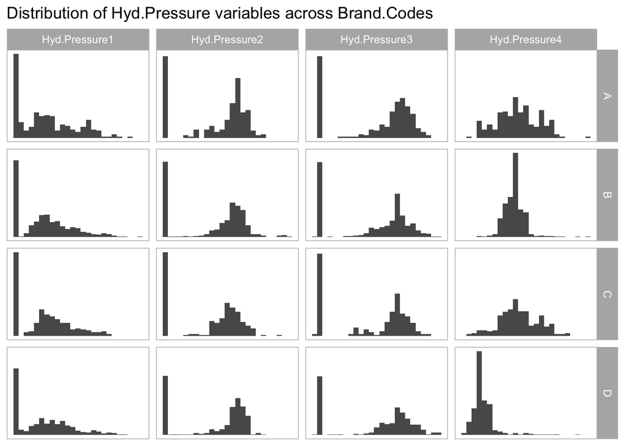

```r
ph_data %>%
  select(Brand.Code, Hyd.Pressure1:Hyd.Pressure4) %>%
  gather(HydNum, Value, -Brand.Code) %>%
  ggplot(aes(x = Value)) +
  geom_histogram(bins = 25) +
  facet_grid(Brand.Code ~ HydNum, scales = "free") +
  theme(panel.grid = element_blank()) +
  scale_x_continuous(NULL, NULL, NULL) +
  scale_y_continuous(NULL, NULL, NULL) +
  ggtitle("Distribution of Hyd.Pressure variables across Brand.Codes")
```

These distributions suggest that there is no behavior in `Hyd.Pressure1`, `Hyd.Pressure2`, or `Hyd.Pressure3` indicated by `Brand.Code`. For this reason, these three variables are dropped. `Hyd.Pressure4` is retained, as there appear to be differences in its behavior across `Brand.Code`:

```r
ph_data <- ph_data %>% select(-(Hyd.Pressure1:Hyd.Pressure3))
```

# Data Preprocessing

Before imputation, the data is split into predictors and a response:

```r
ph_pred <- ph_data %>% select(-PH)
ph_resp <- ph_data %>% select(PH)
```

## Imputation

The operations are applied in this order: zero-variance filter, near-zero variance filter, correlation filter, Box-Cox/Yeo-Johnson/exponential transformation, centering, scaling, range, imputation, PCA, ICA then spatial sign.

```r
library(caret)
# set up pre-processing transformation
ph_preproc <- preProcess(ph_pred, method = c("knnImpute", "center", "scale", "corr"))
# apply pre-processing to data
ph_pred <- predict(ph_preproc, ph_pred)
```

## Partitioning

With pre-processing complete, both predictor and response data are partitioned into a training and testing set:

```r
# get rows for training subsets
set.seed(100)  # for replicability
train_rows <- createDataPartition(ph_resp$PH, p = 0.75, list = FALSE)
# create training sets
ph_pred_train <- ph_pred[train_rows, ]
ph_resp_train <- ph_resp[train_rows, ]
# creae test sets
ph_pred_test <- ph_pred[-train_rows, ]
ph_resp_test <- ph_resp[-train_rows, ]
```

For some models used, the character predictor `Brand.Code` needs to be numeric. Additional data frames (for training & testing) are created with this variable converted:

```r
ph_pred_train_num <- mutate(ph_pred_train, Brand.Code = as.numeric(as.factor(Brand.Code)))
ph_pred_test_num <- mutate(ph_pred_test, Brand.Code = as.numeric(as.factor(Brand.Code)))
```

# Model Creation

## Linear Models

```r
# create single df for fomula based model
regressData <- data.frame(ph_pred_train_num, PH = ph_resp_train, stringsAsFactors = FALSE)
```

### Simple Linear Model

A simple linear model is fit using all of the predictors contained in `ph_pred_train`:

```r
# train model
lmTune <- train(PH ~ ., data = regressData, method = "lm")
# get predictions for test set
lmPred <- predict(lmTune, newdata = ph_pred_test_num)
# evaluate performance of test set
lmPerf <- postResample(pred = lmPred, obs = ph_resp_test)
```

### Generalized Linear Model

Generalized linear models are extended versions of linear models which use a link function to describe the relation of the mean and the linear predictor, and a variance function. GLM can be used to model other distributions, such as binomial, Poisson, and exponential.

```r
# fit model
glmTune <- glm(PH ~ ., data = regressData, family = "quasipoisson")
# get predictions & performance
glmPred <- predict(glmTune, newdata = ph_pred_test_num)
glmPerf <- postResample(pred = glmPred, obs = ph_resp_test)
```

### Principal Components Regression Model

A principal components regression model seeks to lower the number of coefficients in a model by creating combinations of the variables that explain significant portions of the variance in the data. Each of the principal components generated are mutually orthogonal, so there is no risk of autocorrelation between predictors.

```r
library(pls)
# tune model
pcrTune <- pcr(PH ~ ., data = regressData, scale = TRUE, validation = "CV")
```

The performance of the PCR model is investigated across the number of components:

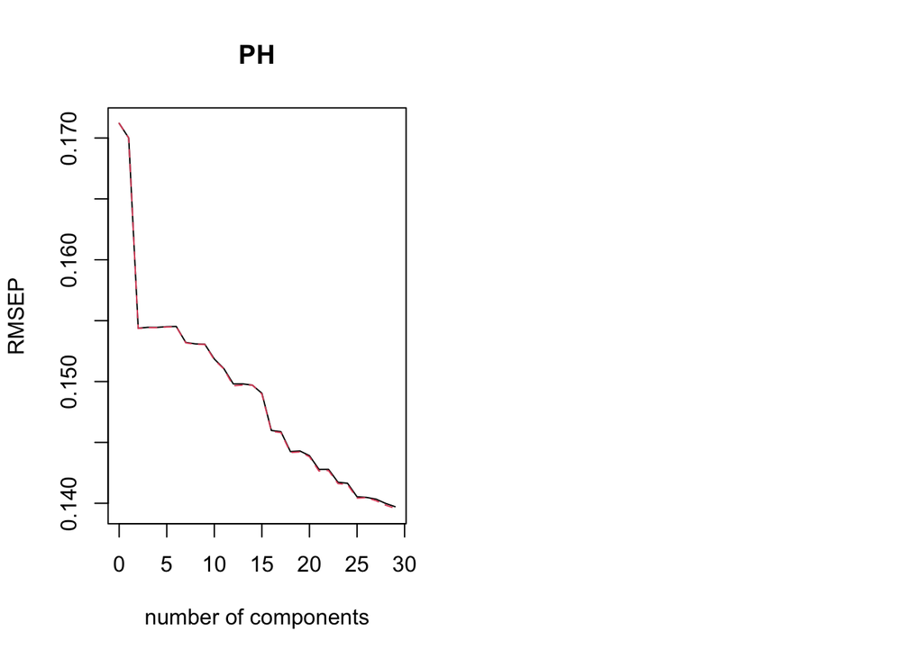

```r
par(mfrow = c(1, 2))
validationplot(pcrTune, val.type = "RMSE")
```

When doing PRC modeling, it is important to keep in mind that the main goal is to see a low cross validation error with a lower number of components than the number of variables in the dataset. In these results, it is clear that the number of components are too high for easy interpretation, resulting in no dimensionality reduction. Based on this, 18 principal components are used for prediction.

```r
# predict & get performance
pcrPred <- predict(pcrTune, newdata = ph_pred_test_num, ncomp = 18)
pcrPerf <- postResample(pred = pcrPred, ph_resp_test)
```

### Stepwise Backwards Linear Regression Model

The PCM model has too many principal components in this model to be easily interpretable. As an alternate, stepwise backwards linear regression is conducted:

```r
# create full model
full <- lm(PH ~ ., data = regressData)
# step backwards
stepTune <- step(full, data = regressData, direction = "backward", trace = FALSE)
pander(summary(stepTune))
```

|  | Estimate | Std. Error | t value | Pr(>\|t\|) |
| --- | --- | --- | --- | --- |
| **(Intercept)** | 8.622 | 0.01535 | 561.7 | 0 |
| **Brand.Code** | -0.02926 | 0.005965 | -4.905 | 1.024e-06 |
| **Fill.Ounces** | -0.0135 | 0.003542 | -3.811 | 0.0001433 |
| **PC.Volume** | -0.006739 | 0.003962 | -1.701 | 0.0891 |
| **Carb.Temp** | 0.006716 | 0.003339 | 2.012 | 0.04443 |
| **PSC.CO2** | -0.008125 | 0.003375 | -2.407 | 0.01617 |
| **Mnf.Flow** | -0.0756 | 0.006588 | -11.48 | 2.152e-29 |
| **Carb.Pressure1** | 0.02894 | 0.004099 | 7.06 | 2.436e-12 |
| **Hyd.Pressure4** | -0.01009 | 0.005227 | -1.931 | 0.05364 |
| **Temperature** | -0.03293 | 0.003747 | -8.787 | 3.74e-18 |
| **Usage.cont** | -0.01618 | 0.004342 | -3.726 | 0.0002007 |
| **Carb.Flow** | 0.01057 | 0.004884 | 2.164 | 0.03059 |
| **Density** | -0.05395 | 0.0132 | -4.087 | 4.576e-05 |
| **Balling** | -0.1315 | 0.03487 | -3.771 | 0.0001683 |
| **Pressure.Vacuum** | -0.02869 | 0.005737 | -5.001 | 6.289e-07 |
| **Oxygen.Filler** | -0.02145 | 0.004344 | -4.939 | 8.657e-07 |
| **Bowl.Setpoint** | 0.02299 | 0.005232 | 4.393 | 1.186e-05 |
| **Pressure.Setpoint** | -0.0122 | 0.004088 | -2.985 | 0.00288 |
| **Alch.Rel** | 0.1121 | 0.01691 | 6.632 | 4.463e-11 |
| **Carb.Rel** | 0.02863 | 0.007595 | 3.769 | 0.0001696 |
| **Balling.Lvl** | 0.06315 | 0.03315 | 1.905 | 0.05691 |

Fitting linear model: PH ~ Brand.Code + Fill.Ounces + PC.Volume + Carb.Temp + PSC.CO2 + Mnf.Flow + Carb.Pressure1 + Hyd.Pressure4 + Temperature + Usage.cont + Carb.Flow + Density + Balling + Pressure.Vacuum + Oxygen.Filler + Bowl.Setpoint + Pressure.Setpoint + Alch.Rel + Carb.Rel + Balling.Lvl

| Observations | Residual Std. Error | $R^2$ | Adjusted $R^2$ |
| --- | --- | --- | --- |
| 1690 | 0.1382 | 0.3561 | 0.3484 |

Predictions and performance are calculated from the stepwise model:

```r
stepPred <- predict(stepTune, newdata = ph_pred_test_num)
stepPerf <- postResample(pred = stepPred, obs = ph_resp_test)
```

## Tree-Based Models

For consistency, the same training controls are used for all tree-based models:

```r
# use 15-fold cross-validation for training
set.seed(100)
mdl_ctrl <- trainControl(method = "cv", number = 15)
```

### Conventional Tree Model

Basic regression trees partition the data based on predictors into groups with a relatively homogeneous distribution of the response variable, and predict the mean of the appropriate group for the response.

```r
library(rpart)
# tree of max depth
set.seed(100)
rpartTune <- train(x = ph_pred_train, y = ph_resp_train,
                   method = "rpart2", trControl = mdl_ctrl)
rpartPred <- predict(rpartTune, newdata = ph_pred_test)
rpartPerf <- postResample(pred = rpartPred, obs = ph_resp_test)
```

### Random Forest Model

While bagging offers a reduction in variance, the trees used are not completely independent of each other, since each tree (and each split of each tree), considers all original predictors. To de-correlate the trees, random forests select a bootstrapped sample of the data, then randomly select a subset of predictors to partition the trees. Once these trees have been fit, the predictions of all models in the ensemble are averaged together.

```r
library(randomForest)
set.seed(100)
rfTune <- train(x = ph_pred_train_num, y = ph_resp_train,
                method = "rf", trControl = mdl_ctrl, importance = TRUE)
rfPred <- predict(rfTune, newdata = ph_pred_test_num)
rfPerf <- postResample(pred = rfPred, obs = ph_resp_test)
```

### Boosted Tree Model

Gradient boosted trees function by attempting to reduce the residuals fit by models. Initially, predictions are simply provided by the mean of the response. A regression tree is then fit based on the residuals between the actual & predicted response. This tree is used to predict the residual, and the difference between the previous residual and the predicted residual is added to the previous residual. This process is repeated for a designated number of iterations, and only the final tree is considered. This is, however, still an ensemble method, as each model fit is informed by the model before it.

```r
library(gbm)
set.seed(100)
boostTune <- train(x = ph_pred_train_num, y = ph_resp_train,
                   method = "gbm", trControl = mdl_ctrl, verbose = FALSE)
boostPred <- predict(boostTune, newdata = ph_pred_test_num)
boostPerf <- postResample(pred = boostPred, obs = ph_resp_test)
```

### Cubist Model

```r
library(Cubist)
set.seed(100)
cubistTune <- train(x = ph_pred_train_num, y = ph_resp_train,
                    method = "cubist", trControl = mdl_ctrl)
cubistPred <- predict(cubistTune, newdata = ph_pred_test_num)
cubistPerf <- postResample(pred = cubistPred, obs = ph_resp_test)
```

# Model Selection & Prediction

## Model Performance Comparison

```r
# function to extract & present model performance
model_perf <- function (model_set, metric = "RMSE") {
  mdl_names <- character()
  Resampled <- numeric()
  Test <- numeric()
  for (mdl in model_set) {
    mdl_names <- c(mdl_names, mdl)
    Resampled <- c(Resampled, min(get(paste0(mdl, "Tune"))$results[[metric]]))
    Test <- c(Test, get(paste0(mdl, "Perf"))[metric])
  }
  pander(data.frame(Resampled, Test, row.names = mdl_names),
         digits = 4, caption = paste(metric, "performance for selected models"))
}
# present performance for 15 models created
#model_perf(c("lm", "glm", "pcr", "step",
#             "mars", "nnet", "svmRadial", "svmLinear", "knn",
#             "rpart", "rule", "bag", "rf", "boost", "cubist"))
```

```r
#model_perf(c("lm", "glm", "pcr", "step",
#             "mars", "nnet", "svmRadial", "svmLinear", "knn",
#             "rpart", "rule", "bag", "rf", "boost", "cubist"),
#           metric = "Rsquared")
```

## Model Investigation

```r
# plot(cubistTune, main = "Performance profile of Cubist model")
```

```r
#cubistImp <- varImp(cubistTune)
#ggplot(cubistImp, top = 10) + ggtitle("Importance of top 10 predictors for cubist model")
```

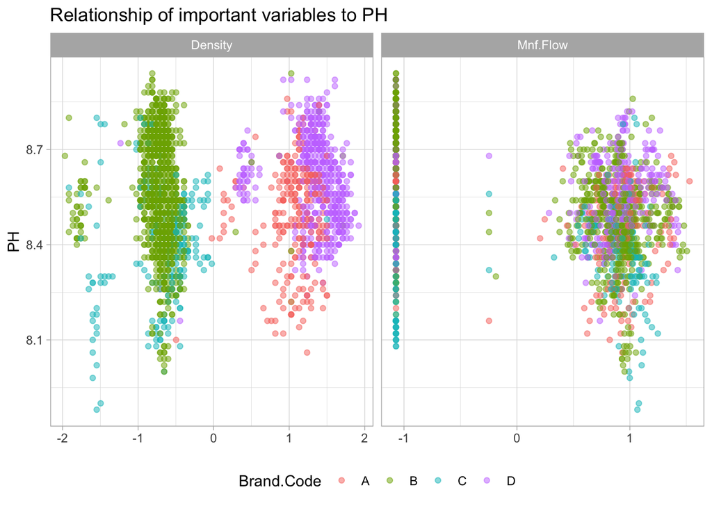

```r
data.frame(ph_pred, ph_resp) %>%
  select(PH, Brand.Code, Mnf.Flow, Density) %>%
  gather(Variable, Value, -c(PH, Brand.Code)) %>%
  ggplot(aes(x = Value, y = PH, col = Brand.Code)) +
  geom_point(alpha = 0.5) +
  facet_wrap(~ Variable, scales = "free_x") +
  theme(legend.position = "bottom") +
  labs(title = "Relationship of important variables to PH", x = NULL)
```

There is not an immediately apparent relationship between `Mnf.flow` and `PH` nor `Brand.Code`, but the relationship between `Density` and `Brand.Code` shows fairly clear clustering behavior. Within each cluster, there appears to be a weakly positive relationship with `PH`.

## Prediction of Additional Data

```r
# read in data
new_data <- read.csv("project2/StudentEvaluation.csv", na.strings = c("", " "), stringsAsFactors = FALSE)
```

The new data is transformed in the same way as the original data:

```r
# remove ph to get only predictors
new_pred <- new_data %>% select(-PH)
# remove Hyd.Pressure1, Hyd.Pressure2, & Hyd.Pressure3
new_pred <- new_pred %>% select(-(Hyd.Pressure1:Hyd.Pressure3))
# perform transformations used for original data
new_pred <- predict(ph_preproc, new_pred)
# convert Brand.Code to numeric
new_pred <- mutate(new_pred, Brand.Code = as.numeric(as.factor(Brand.Code)))
```

Finally, the response is predicted and output:

```r
# predict
cubistTune <- train(x = ph_pred_train_num, y = ph_resp_train,
                    method = "cubist", trControl = mdl_ctrl)
new_resp <- predict(cubistTune, new_pred)
# write predictors & response to csv
# data.frame(new_data, PH = new_resp) %>%
#   write_csv("Data624_Project2_prediction.csv")
```